# Container Deposit Scheme

Brie Sherow

02/04/2021

```r
library(ggplot2) #graphing
library(ggthemes) #graphing templates
library(hrbrthemes) #graphing templates
library(lubridate) #date manipulation
library(forcats) #working with factors
library(tidyverse) #manipulating data
library(knitr) #rmarkdown functions
library(kableExtra) #table layouts
library(tidyr) #long & wide formats
library(reshape2) #melt function for wide and long formats
library(RColorBrewer)
#library(cowplot) #minimal backgrounds for ggplot
```

# Data

Survey data from Tangaroa Blue “Strain the Drains” project. Nine survey cycles, collected in 6-week intervals from October 2019 to October 20. Cycle 8, being a partial survey round with assets re-surveyed in cycle 9, was merged with cycle 9.

```r
#create survey count

        #load item counts
        item <- read.csv(file="Data/2101_item.csv",
                         header=T, sep=",")

  #remove duplicate entries
        item <- unique(item[!duplicated(item),])

        #load item labels
        item_label <- read.csv(file="Data/item_label.csv",
                         header=T, sep=",")

        #load events
        event <- read.csv(file="Data/2101_event.csv",
                         header=T, sep=",")

        #join event info to item count
        survey_count <- left_join(item, event, by="event_id")

        survey_count <- survey_count %>%
          dplyr::select(-event.tot, -event.wt, -vol, -hr, -event_date, -note) %>%
          filter(item!="Pollution Rating") %>%
          mutate(event_item = paste(event_id, item, sep=" "))

        #summarise duplicate survey entries (this will lose one set of notes....)
        item_merge <- survey_count %>%
          group_by(event_item) %>%
          summarise(sum=sum(total)) %>%
         ungroup()

        #join survey count to the merged summaries
        survey_count <- item_merge %>%
          left_join(survey_count, by="event_item") %>%
          dplyr::select(-total) %>%
          unique()

#create abundance data with all possible debris items and zero values

      #count of items per unique event
      event_count <- survey_count %>%
        group_by(event_id, item) %>%
        summarise(sum=sum(sum)) %>%
        ungroup()

      #load AMDI code\
      AMDI_code <- read.csv(file="Data/200101_AMDI_code.csv",
                       header=T, sep=",")

      #create full list of possible items
      AMDI <- AMDI_code %>%
        filter(item_code_id != "LSTD1") %>% #remove pollution rating / microplastics
        dplyr::select(item.ex) #column of all possible item types


      #create a df of all possible items at all survey events, complete with zeros
      abund <- full_join(AMDI, event_count, by=c("item.ex" = "item"))

      #remove empty row
      abund <- abund[-11613, ]

      #data long to wide
      abund_wide <- spread(abund, item.ex, sum)

      #replace na values with 0
      abund_wide[is.na(abund_wide)] <- 0

      #transform back to long but now with the full items list and zero data
      abund_long <- melt(abund_wide, id.vars="event_id")

      #remove the zero event ID (how did that get there?)
      abund_long <- abund_long[abund_long$event_id != 0, ]

      #create event_item column for joining
      abund_long <- abund_long %>%
      mutate(event_item = paste(event_id, variable, sep=" "))

#join abundance data to survey notes and other columns
  df <- left_join(abund_long, survey_count, by="event_item")

  df <- df %>%
    dplyr::select(-event_item, -event_id.y, -item, -sum) %>% #remove duplicate columns
    rename(event_id=event_id.x,
           item=variable,
           sum=value) %>% #rename columns
    arrange(event_id, Asset.ID) %>% #arrange by event so that missing values are aligned
    fill(Asset.ID, Cycle, date, covid) #fill in missing values to match survey data

  #clean up column classifications

  #reclassify columns to factor
    names <- c("event_id", "Asset.ID", "Cycle")

    df[,names] <- lapply(df[,names], factor)

  #reclassify date
    df$date <- dmy(df$date)

#join land use zone and LGA

    #load sites
        site <- read.csv(file="Data/200619_site.csv",
                         header=T, sep=",")

    #join LGA and luz to df
        df <- left_join(df, site, by = "Asset.ID")

    #remove unecessary columns
        df <- df %>%
          dplyr::select(-Site, -Latitude, -Longitude)

#resolve duplicates in MC01, C5
        dup <- df %>%
          group_by(Asset.ID, Cycle, item) %>% #reconcile duplicates in MC01 Cycle 5
          summarise(sum=sum(sum)) %>%
          ungroup() %>%
          mutate(join = paste(Asset.ID, Cycle, item, sep=" "))

    # #check difference
    #      subsetdf <- df %>%
    #        dplyr::select(Asset.ID, Cycle, item, sum)
    #
    #      setdiff(subsetdf, dup)

    #join C5 correction to df
         df <- df %>%
           mutate(join = paste(Asset.ID, Cycle, item, sep=" "))

    df <- dup %>% left_join(df, by="join") %>%
      dplyr::select(-join, -item.y, -sum.y, -Asset.ID.y, -Cycle.y) %>%
      filter(event_id != "23097") %>%
      rename(
          asset_id = Asset.ID.x,
          cycle = Cycle.x,
          item = item.x,
          sum = sum.x,
          LUZ = Land.use.zone,
      ) %>%
      distinct()

    item_labelDF <- df %>%
      distinct(item)

    df <- df %>%
      left_join(item_label, by=c("item" = "item.type")) %>%
      mutate(item = A3) %>%
      dplyr::select(-A3)


 #lost_items <- anti_join(item_label, item_labelDF, by=c("item.type"="item"))

  # df <- df %>%
  #   filter(cycle %in% paste0("C",1:7))
    df <- df %>%
      mutate(asset_id=as.factor(asset_id),
             item=as.factor(item),
             LGA=as.factor(LGA),
             LUZ=as.factor(LUZ)
             )

#combine cycles 8 and 9
      #isolate C8
      C8 <- df %>%
        filter(cycle == "C8")

      #isolate C9
      C9 <- df %>%
        filter(cycle == "C9")

      #join C8 and C9 by unique drain and item to capture double surveys
      t <- left_join(C9, C8, by=c("asset_id"="asset_id", "item" = "item"))
      t$sum.y[is.na(t$sum.y)] <- 0 #change na to 0

      t <- t %>%
        mutate(combined_sum = sum.y + sum.x) %>% #add C8 and C9 together
        dplyr::select(event_id.x, item, combined_sum)

      df <- df %>%
        left_join(t, by = c("event_id"="event_id.x", "item"="item")) %>%
        filter(cycle != "C8") %>%
        mutate(combined_sum = replace_na(combined_sum, 0),
                sum2 = ifelse(cycle != "C9", sum, 0),
                final_sum = sum2 + combined_sum) %>%
        dplyr::select(-sum2, -sum, -combined_sum) %>%
        rename(sum = final_sum)
```

# Container Deposit Scheme

Items included in Victoria’s ‘Container Deposit Scheme’ include drink cartons, beer bottles, aluminum cans, and plastic drink bottles. The results of a full year of surveys indicate that aluminum cans and plastic drink bottles are more abundant than beer bottles and drink cartons in selected Melbourne storm drains. These totals are likely low due to the Covid-19 lockdowns from March through October 2020.

```r
CDS <- df %>%
  filter(cycle %in% paste0("C",1:9)) %>%
  filter(item %in% c("Drink cartons",
                     "Beer bottles (and similar)",
                     "Aluminium cans",
                     "Plastic drink bottles"))

#Find the top item types across all surveys
CDS_totals <- CDS %>%
  group_by(item) %>%
  mutate(total=sum(sum)) %>% #sum of total items by type and land use %>%
        dplyr::select(item, total) %>% #remove irrelevant columns
        filter(total>0) %>% #remove zero values
        distinct() %>% #remove duplicate entries
        ungroup()

CDS_kable_tot <- CDS_totals %>%
  mutate_if(is.numeric, format, digits=2) %>%
  kable("html",
      col.names = c("Debris Type", "Total"),
      caption = "Debris count: sum of all surveys") %>%
  kable_styling(bootstrap_options="condensed", position="left")
CDS_kable_tot #print table
```

Debris count: sum of all surveys

| Debris Type | Total |
| --- | --- |
| Aluminium cans | 594 |
| Beer bottles (and similar) | 58 |
| Plastic drink bottles | 596 |
| Drink cartons | 36 |

```r
save_kable(CDS_kable_tot, "Output/CDS_kable_tot.png") #save table as png
```

# Pre-Covid results

This table shows results from the first four survey rounds, pre-Covid lockdown.

```r
#Find the top item types across all surveys
CDS_cycle <- CDS %>%
  filter(cycle %in% paste0("C", 1:4)) %>%
  group_by(item) %>%
  mutate(total=sum(sum),
         cycle_sum= total/4) %>% #sum of total items by type and land use %>%
        dplyr::select(item, total, cycle_sum) %>% #remove irrelevant columns
        filter(total>0) %>% #remove zero values
        distinct() %>% #remove duplicate entries
        ungroup()

CDS_kable_cycle <- CDS_cycle %>%
  mutate_if(is.numeric, format, digits=0) %>%
  kable("html",
      col.names = c("Debris Type", "Pre-Covid Total", "Every 6 weeks"),
      caption = "Debris Count: Oct 2019 to March 2020") %>%
  kable_styling(bootstrap_options="condensed", position="left")
CDS_kable_cycle #print table
```

Debris Count: Oct 2019 to March 2020

| Debris Type | Pre-Covid Total | Every 6 weeks |
| --- | --- | --- |
| Aluminium cans | 381 | 95 |
| Beer bottles (and similar) | 35 | 9 |
| Plastic drink bottles | 324 | 81 |
| Drink cartons | 19 | 5 |

```r
save_kable(CDS_kable_cycle, "Output/CDS_kable_cycle.png") #save table as png
```

# Pre-Covid by land use

```r
#find means per luz in each pre-covid cycle
CDS_cycle_LUZ <- CDS %>%
  filter(cycle %in% paste0("C", 1:4)) %>%
  group_by(item, LUZ) %>%
  summarise(total=sum(sum),
            mean=mean(total)/4,
            sd=sd(sum))

#function to collapse rows
collapse_rows_df <- function(df, variable){
  group_var <- enquo(variable)
  df %>%
    group_by(!! group_var) %>%
    mutate(groupRow = 1:n()) %>%
    ungroup() %>%
    mutate(!!quo_name(group_var) := ifelse(groupRow == 1, as.character(!! group_var), "")) %>%
    select(-c(groupRow))
}

CDS_kable_LUZ <- CDS_cycle_LUZ %>%
  mutate_if(is.numeric, format, digits=0) %>%
  dplyr::select(-item) %>%
  collapse_rows_df(item) %>%
  kable("html",
      col.names = c("Debris Type", "Land use zone", "Pre-Covid Total", "Every 6 weeks", "SD"),
      caption = "Debris Count by Land Use: Oct 2019 to March 2020") %>%
  kable_styling(bootstrap_options="condensed", position="left")
CDS_kable_LUZ #print table
```

Debris Count by Land Use: Oct 2019 to March 2020

| Debris Type | Land use zone | Pre-Covid Total | Every 6 weeks | SD |
| --- | --- | --- | --- | --- |
| Aluminium cans | CBD | 104 | 26 | 1 |
|  | Industrial Precinct | 101 | 25 | 1 |
|  | Public Transport Terminal | 96 | 24 | 1 |
|  | Shopping Centre | 80 | 20 | 1 |
| Beer bottles (and similar) | CBD | 15 | 4 | 0 |
|  | Industrial Precinct | 1 | 0 | 0 |
|  | Public Transport Terminal | 13 | 3 | 0 |
|  | Shopping Centre | 6 | 2 | 0 |
| Drink cartons | CBD | 4 | 1 | 0 |
|  | Industrial Precinct | 3 | 1 | 0 |
|  | Public Transport Terminal | 7 | 2 | 0 |
|  | Shopping Centre | 5 | 1 | 0 |
| Plastic drink bottles | CBD | 73 | 18 | 1 |
|  | Industrial Precinct | 94 | 24 | 1 |
|  | Public Transport Terminal | 95 | 24 | 1 |
|  | Shopping Centre | 62 | 16 | 1 |

```r
# save_kable(CDS_kable_cycle, "Output/CDS_kable_cycle.png") #save table as png
```

# Pre-Covid results by land use

Graphical representation of the table above. Note the y-scale is free, so for example the variation in beer bottles and drink cartons looks greater than it is.

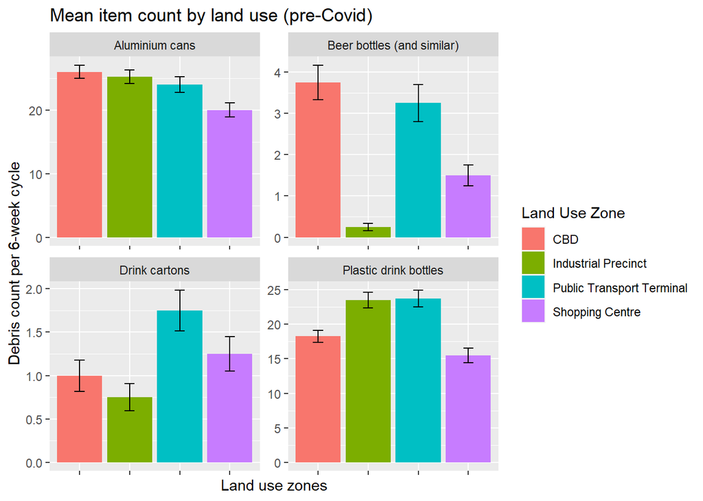

```r
CDS_cycle_LUZ %>%
  ggplot(aes(LUZ, mean, fill=LUZ)) +
  labs(fill="Land Use Zone") +
  geom_bar(position="dodge", stat="identity") +
  geom_errorbar(aes(ymin=mean-sd, ymax=mean+sd, width=0.2), position=position_dodge(width=0.90)) +
  theme(axis.text.x = element_blank()) +
  ylab("Debris count per 6-week cycle") +
  xlab("Land use zones") +
  ggtitle("Mean item count by land use (pre-Covid)") +
  facet_wrap(~item, scales="free")
```

# Impact of Covid-19

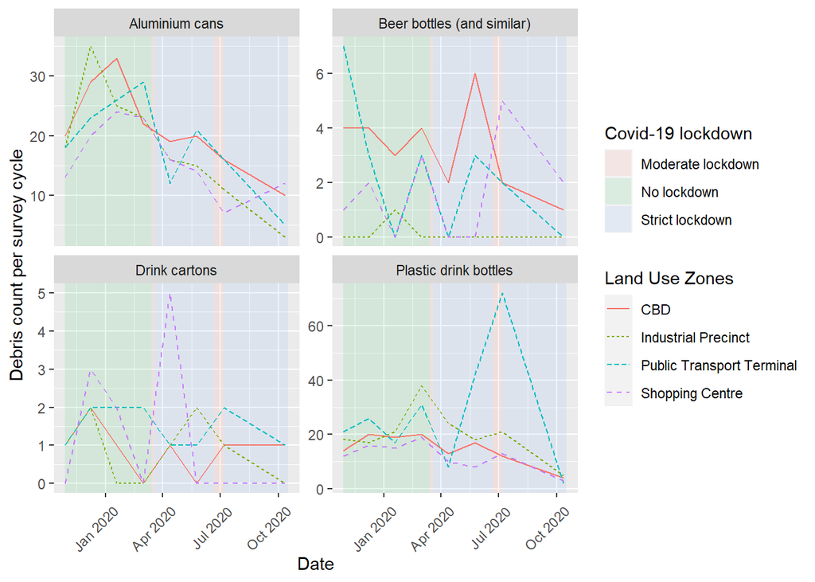

```r
item_per_cycle <- CDS %>%
  group_by(date, covid, LUZ, item) %>%
  summarise(cycle_sum = sum(sum))

covid_lvl <- data.frame(name = c("1", "2", "3", "4", "5"),
                   start = as.Date(c("2019-10-29", "2020-03-14", "2020-03-19", "2020-06-21",
                             "2020-07-07")),
                   end = as.Date(c("2020-03-14", "2020-03-19", "2020-06-21", "2020-07-07",
                           "2020-10-17")),
                   level = c("No lockdown", "Moderate lockdown", "Strict lockdown", "Moderate lockdown", "Strict lockdown"),
                   stringsAsFactors = FALSE) %>%
  mutate(median_x = start + floor((end-start)/2))


p <- ggplot() +
  geom_rect(data=covid_lvl, aes(NULL, NULL, xmin=start, xmax=end, fill=level,
                                ymin= -Inf, ymax=Inf), alpha=0.1) +
  labs(fill="Covid-19 lockdown", linetype="Land Use Zones", colour="Land Use Zones",
       x="Date", y="Debris count per survey cycle") +
  # geom_point(data=item_per_cycle, aes(date, cycle_sum, color=LUZ)) +
  geom_line(data=item_per_cycle, aes(date, cycle_sum, linetype=LUZ, color=LUZ)) +
  theme(axis.text.x=element_text(angle=45, vjust=0.75, hjust=0.8)) +
  facet_wrap(~item, scales="free_y")
  # theme_cowplot(12)
p
```